# Task 2,4 & 5

### Task No. 2

**`Perform hierarchical clustering on a dataset. Use dendrograms to decide the number of clusters`**.

[output not shown]

### Hierarchical Clustering

**Hierarchical clustering** (also called hierarchical cluster analysis or HCA) is a method of cluster analysis which seeks to build a hierarchy of clusters. Strategies for hierarchical clustering generally fall into two types:

- **Agglomerative**: This is a "bottom-up" approach: each observation starts in its own cluster, and pairs of clusters are merged as one moves up the hierarchy.
- **Divisive**: This is a "top-down" approach: all observations start in one cluster, and splits are performed recursively as one moves down the hierarchy.

In general, the merges and splits are determined in a greedy manner. The results of hierarchical clustering are usually presented in a dendrogram.

### Agglomerative Clustering

Initially, each data point is considered as an individual cluster. At each iteration, the similar clusters merge with other clusters until 1/K clusters are formed.

The main advantage is that we don’t need to specify the number of clusters. However, this comes with a price: performance (O(n^3)). In sklearn’s implementation, we can specify the number of clusters to assist the algorithm’s performance.

### Algorithm

- Compute the proximity matrix
- Let each data point be a cluster
- Repeat: Merge two closest clusters and update the proximity matrix until 1/K cluster remains

### Section-1 : Exploring Dataset

```python
import numpy as np # linear algebra
import pandas as pd # data processing, CSV file I/O (e.g. pd.read_csv)
import matplotlib.pyplot as plt # for data visualization
import seaborn as sns # for statistical data visualization
%matplotlib inline
import warnings
warnings.filterwarnings('ignore')
import os

import plotly.express as px
import plotly.figure_factory as ff
from sklearn.preprocessing import LabelEncoder
from sklearn.preprocessing import MinMaxScaler
from sklearn.cluster import KMeans
from sklearn.manifold import TSNE
from mpl_toolkits.mplot3d import Axes3D
from sklearn.decomposition import PCA
import scipy.cluster.hierarchy as shc
from sklearn.cluster import AgglomerativeClustering

live = pd.read_csv(r"C:\Users\acer\Downloads\Live.csv")
live.drop(['status_id', 'status_published', 'status_type'], axis=1, inplace=True)
```

```python
live.head()
```

|  | num_reactions | num_comments | num_shares | num_likes | num_loves | num_wows | num_hahas | num_sads | num_angrys |
| --- | --- | --- | --- | --- | --- | --- | --- | --- | --- |
| 0 | 529 | 512 | 262 | 432 | 92 | 3 | 1 | 1 | 0 |
| 1 | 150 | 0 | 0 | 150 | 0 | 0 | 0 | 0 | 0 |
| 2 | 227 | 236 | 57 | 204 | 21 | 1 | 1 | 0 | 0 |
| 3 | 111 | 0 | 0 | 111 | 0 | 0 | 0 | 0 | 0 |
| 4 | 213 | 0 | 0 | 204 | 9 | 0 | 0 | 0 | 0 |

### Section-2: Normalization

```python
X = live
cols = X.columns
ms = MinMaxScaler()
X = ms.fit_transform(X)
X = pd.DataFrame(X, columns=[cols])
X.head()
```

|  | num_reactions | num_comments | num_shares | num_likes | num_loves | num_wows | num_hahas | num_sads | num_angrys |
| --- | --- | --- | --- | --- | --- | --- | --- | --- | --- |
| 0 | 0.112314 | 0.024393 | 0.076519 | 0.091720 | 0.140030 | 0.010791 | 0.006369 | 0.019608 | 0.0 |
| 1 | 0.031847 | 0.000000 | 0.000000 | 0.031847 | 0.000000 | 0.000000 | 0.000000 | 0.000000 | 0.0 |
| 2 | 0.048195 | 0.011243 | 0.016647 | 0.043312 | 0.031963 | 0.003597 | 0.006369 | 0.000000 | 0.0 |
| 3 | 0.023567 | 0.000000 | 0.000000 | 0.023567 | 0.000000 | 0.000000 | 0.000000 | 0.000000 | 0.0 |
| 4 | 0.045223 | 0.000000 | 0.000000 | 0.043312 | 0.013699 | 0.000000 | 0.000000 | 0.000000 | 0.0 |

### Section-3 : Heirachial Clustering

### Dendograms Visualization

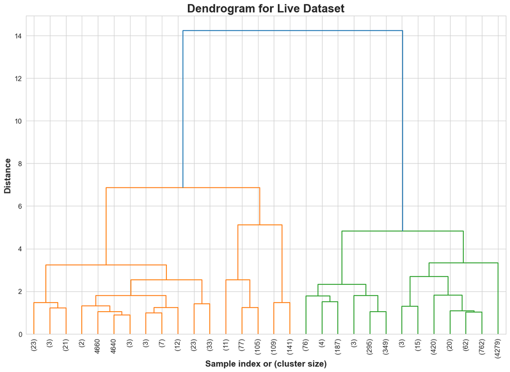

```python
# Perform hierarchical clustering
linked = linkage(X_scaled, method='ward')
# Create a figure and axis object
fig, ax = plt.subplots(figsize=(15, 10))
# Set the seaborn style
sns.set_style('whitegrid')

# Plot the dendrogram
dendrogram(linked,
           ax=ax,  # Pass the axis object to dendrogram
           truncate_mode='lastp',
           p=30,
           show_leaf_counts=True,
           leaf_rotation=90.,  # Rotate leaf labels for better readability
           leaf_font_size=12,  # Increase font size for leaf labels
           count_sort='ascending'  # Sort clusters by size
          )

# Set the title and labels
ax.set_title("Dendrogram for Live Dataset", fontsize=20, fontweight='bold')
ax.set_xlabel('Sample index or (cluster size)', fontsize=15, fontweight='bold')
ax.set_ylabel('Distance', fontsize=15, fontweight='bold')

# Set the tick font sizes
ax.tick_params(axis='x', labelsize=12)
ax.tick_params(axis='y', labelsize=12)

# Show the plot
plt.show()
```

### Optimal Clusters Finding

```python
# Determine the optimal number of clusters using Silhouette Score
range_n_clusters = list(range(2, 11))  # Test 2 to 10 clusters
silhouette_avg = []

for num_clusters in range_n_clusters:
    clusters = fcluster(linked, num_clusters, criterion='maxclust')
    silhouette_avg.append(silhouette_score(X_scaled, clusters))

optimal_clusters = range_n_clusters[silhouette_avg.index(max(silhouette_avg))]
print(f"Optimal number of clusters based on silhouette score: {optimal_clusters}")
```

```
Optimal number of clusters based on silhouette score: 3
```

### Section-4 : Visualizing Clusters

| Step | Description |
| --- | --- |
| 1. 2D Clusters Visualization using PCA | Generate and plot 2D visualizations of clusters after applying Principal Component Analysis (PCA) to reduce dimensionality. Analyze how the clusters are distributed in the 2D PCA space. |
| 2. 2D Clusters Visualization using t-SNE | Create 2D visualizations of clusters using t-SNE (t-Distributed Stochastic Neighbor Embedding) to preserve the local structure of the data and examine the clustering patterns in 2D space. |

### Clusters in 2D Space using t-SNE

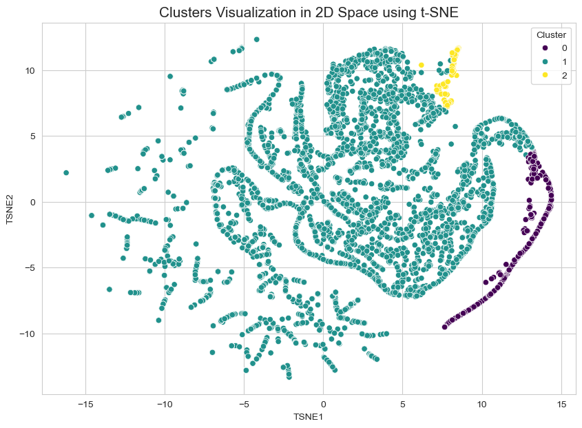

```python
# Fit hierarchical clustering with the optimal number of clusters
hc_model = AgglomerativeClustering(n_clusters=optimal_clusters, metric='euclidean', linkage='ward')
clusters = hc_model.fit_predict(X_scaled)

# Add cluster labels to the dataset
X['Cluster'] = clusters

# 2D Visualization using t-SNE
tsne = TSNE(n_components=2, perplexity=30, n_iter=300)
X_tsne = tsne.fit_transform(X_scaled)
X['TSNE1'] = X_tsne[:, 0]
X['TSNE2'] = X_tsne[:, 1]

plt.figure(figsize=(10, 7))
sns.scatterplot(x='TSNE1', y='TSNE2', hue='Cluster', data=X, palette='viridis')
plt.title('Clusters Visualization in 2D Space using t-SNE', fontsize=15)
plt.show()
```

### Clusters in 2D Space using PCA

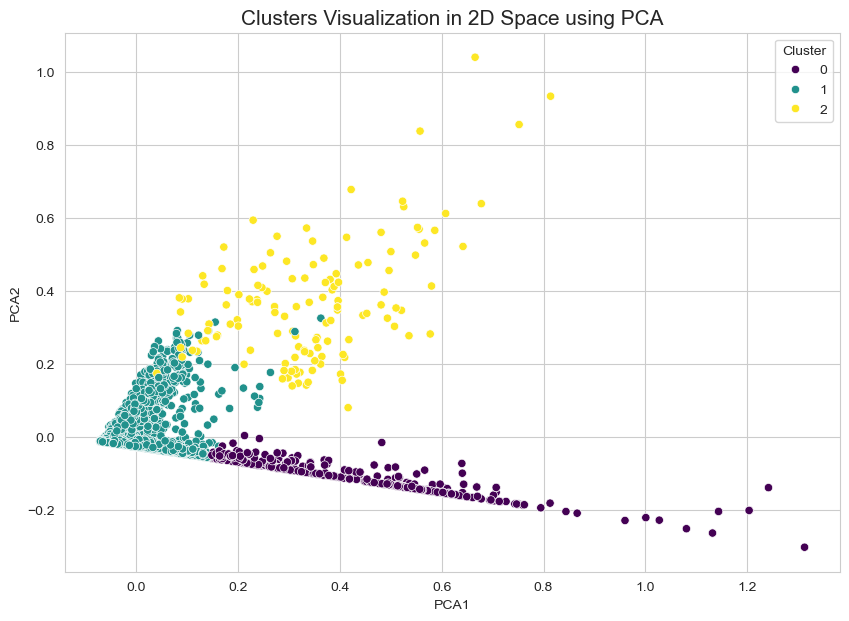

```python
# 2D Visualization using PCA
pca = PCA(n_components=2)
X_pca = pca.fit_transform(X_scaled)
X['PCA1'] = X_pca[:, 0]
X['PCA2'] = X_pca[:, 1]

plt.figure(figsize=(10, 7))
sns.scatterplot(x='PCA1', y='PCA2', hue='Cluster', data=X, palette='viridis')
plt.title('Clusters Visualization in 2D Space using PCA', fontsize=15)
plt.show()
```

### Task No. 4

**`Use Gaussian Mixture Models (GMM) for clustering. Visualize the probability distributions of the cluster.`**.

[output not shown]

### Section-1 : Importing Libraries & Dataset

```python
import pandas as pd
import numpy as np
import matplotlib.pyplot as plt
from sklearn.mixture import GaussianMixture
from sklearn.decomposition import PCA
from sklearn.manifold import TSNE
```

## Gaussian Mixture Models (GMM)

**Gaussian Mixture Models (GMMs)** are a probabilistic model used to represent a mixture of multiple Gaussian distributions. They are widely used for clustering, density estimation, and pattern recognition.

### Key Concepts

- **Gaussian Distribution:** GMM assumes that the data is generated from a mixture of several Gaussian distributions, each characterized by its mean and covariance.
- **Mixture Components:** Each Gaussian component in the mixture represents a cluster or group within the data. The GMM aims to determine the parameters of these components that best fit the data.
- **Expectation-Maximization (EM) Algorithm:** The parameters of the GMM are typically estimated using the EM algorithm, which iteratively refines the estimates to maximize the likelihood of the observed data.
- **Applications:**
  - **Clustering:** GMMs are used for clustering by assigning data points to the Gaussian component with the highest probability.
  - **Density Estimation:** GMMs can model the underlying distribution of the data, which can be useful for anomaly detection and other applications.

### Advantages

- **Flexibility:** GMMs can model more complex data distributions compared to single Gaussian models.
- **Soft Clustering:** Unlike K-Means, which assigns each data point to a single cluster, GMMs provide a probability distribution over clusters, allowing for soft clustering.

### Limitations

- **Assumption of Gaussian Distribution:** GMM assumes that the data is generated from Gaussian distributions, which may not always be true.
- **Sensitivity to Initialization:** The results of GMM can be sensitive to the initial parameter estimates, requiring careful initialization or multiple runs to ensure robustness.

### Section-2 : Finding Optimal Components Number

```python
n_components_range = range(2, 10)  # adjust the range as needed
bics = []
aics = []

for n in n_components_range:
    gmm = GaussianMixture(n_components=n, random_state=42)
    gmm.fit(X)
    bics.append(gmm.bic(X))
    aics.append(gmm.aic(X))

optimal_n_components_bic = n_components_range[np.argmin(bics)]
optimal_n_components_aic = n_components_range[np.argmin(aics)]
```

### Section-3 : Visualizing Components

### 1. Optimal Components In 2D

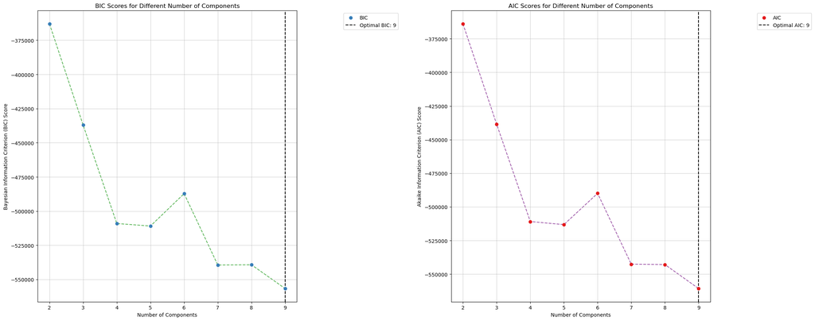

```
Optimal number of components (BIC): 9
Optimal number of components (AIC): 9
```

```python
# Plot BIC and AIC scores with enhanced visuals
plt.figure(figsize= (23, 9))

# Plot BIC scores with scatter plot and trend line
plt.subplot(1, 2, 1)
plt.scatter(n_components_range, bics, color='#377eb8', label='BIC', zorder=5)
plt.plot(n_components_range, bics, color='#4daf4a', linestyle='--', alpha=0.9, zorder=1)
plt.axvline(optimal_n_components_bic, color='black', linestyle='--', label=f'Optimal BIC: {optimal_n_components_bic}')
plt.xlabel('Number of Components')
plt.ylabel('Bayesian Information Criterion (BIC) Score')
plt.title('BIC Scores for Different Number of Components')
plt.legend(loc='upper right', bbox_to_anchor=(1.4, 1))
plt.grid(True, linestyle='-', alpha=0.6)

# Plot AIC scores with scatter plot and trend line
plt.subplot(1, 2, 2)
plt.scatter(n_components_range, aics, color='#e41a1c', label='AIC', zorder=5)
plt.plot(n_components_range, aics, color='#984ea3', linestyle='--', alpha=0.9, zorder=1)
plt.axvline(optimal_n_components_aic, color='black', linestyle='--', label=f'Optimal AIC: {optimal_n_components_aic}')
plt.xlabel('Number of Components')
plt.ylabel('Akaike Information Criterion (AIC) Score')
plt.title('AIC Scores for Different Number of Components')
plt.legend(loc='upper right', bbox_to_anchor=(1.4, 1))
plt.grid(True, linestyle='-', alpha=0.6)

plt.tight_layout()
plt.show()

print(f'Optimal number of components (BIC): {optimal_n_components_bic}')
print(f'Optimal number of components (AIC): {optimal_n_components_aic}')
```

### 2. Optimal Components In 3D

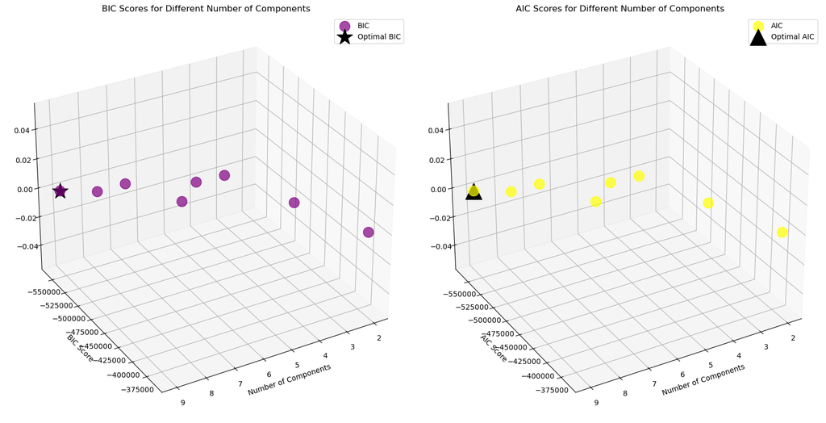

```
Optimal number of components (BIC): 9
Optimal number of components (AIC): 9
```

```python
# Plot BIC and AIC scores with enhanced visuals
fig = plt.figure(figsize=(16, 8))

# Plot BIC scores with 3D scatter plot
ax = fig.add_subplot(1, 2, 1, projection='3d')
ax.scatter(n_components_range, bics, np.zeros_like(bics), c='purple', label='BIC', s=200, alpha=0.7)
ax.scatter(optimal_n_components_bic, min(bics), 0, c='black', s=500, marker='*', edgecolor='black', label='Optimal BIC', zorder=5)

ax.set_xlabel('Number of Components')
ax.set_ylabel('BIC Score')
ax.set_zlabel('')
ax.set_title('BIC Scores for Different Number of Components')
ax.view_init(elev=30, azim=60)
ax.legend()

# Plot AIC scores with 3D scatter plot
ax = fig.add_subplot(1, 2, 2, projection='3d')
ax.scatter(n_components_range, aics, np.zeros_like(aics), c='yellow', label='AIC', s=200, alpha=0.7)
ax.scatter(optimal_n_components_aic, min(aics), 0, c='black', s=500, marker='^', edgecolor='black', label='Optimal AIC', zorder=5)
ax.set_xlabel('Number of Components')
ax.set_ylabel('AIC Score')
ax.set_zlabel('')
ax.set_title('AIC Scores for Different Number of Components')
ax.view_init(elev=30, azim=60)
ax.legend()

plt.tight_layout()
plt.show()

print(f'Optimal number of components (BIC): {optimal_n_components_bic}')
print(f'Optimal number of components (AIC): {optimal_n_components_aic}')
```

### Section-4 : Scores For Different Components

```python
# Convert X_pca to a pandas DataFrame
gmm = GaussianMixture(n_components=9, random_state=0)
gmm.fit(X)
clusters_gmm = gmm.predict(X)

# Now you can add the cluster labels to the DataFrame
X['Cluster_GMM'] = clusters_gmm
#36
# Calculate Silhouette Score
silhouette_avg = silhouette_score(X, clusters_gmm)
print(f'Silhouette Score: {silhouette_avg:.4f}')

# Calculate Davies-Bouldin Score
davies_bouldin_avg = davies_bouldin_score(X, clusters_gmm)
print(f'Davies-Bouldin Score: {davies_bouldin_avg:.4f}')
```

[output not shown]

## DIFFERENT COMPONENTS SCORES

```python
#36
# Calculate Silhouette Score
silhouette_avg = silhouette_score(X, clusters_gmm)
print(f'Silhouette Score: {silhouette_avg:.4f}')

# Calculate Davies-Bouldin Score
davies_bouldin_avg = davies_bouldin_score(X, clusters_gmm)
print(f'Davies-Bouldin Score: {davies_bouldin_avg:.4f}')
```

```
Silhouette Score: 0.7014
Davies-Bouldin Score: 1.0387
```

```python
#33
# Calculate Silhouette Score
silhouette_avg = silhouette_score(X, clusters_gmm)
print(f'Silhouette Score: {silhouette_avg:.4f}')

# Calculate Davies-Bouldin Score
davies_bouldin_avg = davies_bouldin_score(X, clusters_gmm)
print(f'Davies-Bouldin Score: {davies_bouldin_avg:.4f}')
```

```
Silhouette Score: 0.7000
Davies-Bouldin Score: 1.1064
```

```python
#42
# Calculate Silhouette Score
silhouette_avg = silhouette_score(X, clusters_gmm)
print(f'Silhouette Score: {silhouette_avg:.4f}')

# Calculate Davies-Bouldin Score
davies_bouldin_avg = davies_bouldin_score(X, clusters_gmm)
print(f'Davies-Bouldin Score: {davies_bouldin_avg:.4f}')
```

```
Silhouette Score: 0.6984
Davies-Bouldin Score: 1.0851
```

```python
#48
# Calculate Silhouette Score
silhouette_avg = silhouette_score(X, clusters_gmm)
print(f'Silhouette Score: {silhouette_avg:.4f}')

# Calculate Davies-Bouldin Score
davies_bouldin_avg = davies_bouldin_score(X, clusters_gmm)
print(f'Davies-Bouldin Score: {davies_bouldin_avg:.4f}')
```

```
Silhouette Score: 0.6868
Davies-Bouldin Score: 1.2257
```

```python
#10
silhouette_avg = silhouette_score(X, clusters_gmm)
print(f'Silhouette Score: {silhouette_avg:.4f}')

# Calculate Davies-Bouldin Score
davies_bouldin_avg = davies_bouldin_score(X, clusters_gmm)
print(f'Davies-Bouldin Score: {davies_bouldin_avg:.4f}')
```

```
Silhouette Score: 0.6088
Davies-Bouldin Score: 1.3709
```

```python
# 23
silhouette_avg = silhouette_score(X, clusters_gmm)
print(f'Silhouette Score: {silhouette_avg:.4f}')

# Calculate Davies-Bouldin Score
davies_bouldin_avg = davies_bouldin_score(X, clusters_gmm)
print(f'Davies-Bouldin Score: {davies_bouldin_avg:.4f}')
```

```
Silhouette Score: 0.6687
Davies-Bouldin Score: 1.1990
```

```python
#28
# Calculate Silhouette Score
silhouette_avg = silhouette_score(X, clusters_gmm)
print(f'Silhouette Score: {silhouette_avg:.4f}')

# Calculate Davies-Bouldin Score
davies_bouldin_avg = davies_bouldin_score(X, clusters_gmm)
print(f'Davies-Bouldin Score: {davies_bouldin_avg:.4f}')
```

```
Silhouette Score: 0.6983
Davies-Bouldin Score: 1.1045
```

```python
#35
# Calculate Silhouette Score
silhouette_avg = silhouette_score(X, clusters_gmm)
print(f'Silhouette Score: {silhouette_avg:.4f}')

# Calculate Davies-Bouldin Score
davies_bouldin_avg = davies_bouldin_score(X, clusters_gmm)
print(f'Davies-Bouldin Score: {davies_bouldin_avg:.4f}')
```

```
Silhouette Score: 0.7016
Davies-Bouldin Score: 1.0838
```